# Puppy Small Dog Analysis

Tom Kremer

Last Updated: 2026-01-05

### Preprocessing Notes

1. This page shows the results for all survey questions split by Q3 between “Less than 20 pounds”, labeled “Small Dogs” and all others.

## Introductory Questions (All Respondents)

## S5

**S5: What is your age, in years?**

4002 non-empty/NA responses out of 4002 possible responses ( 100 %)

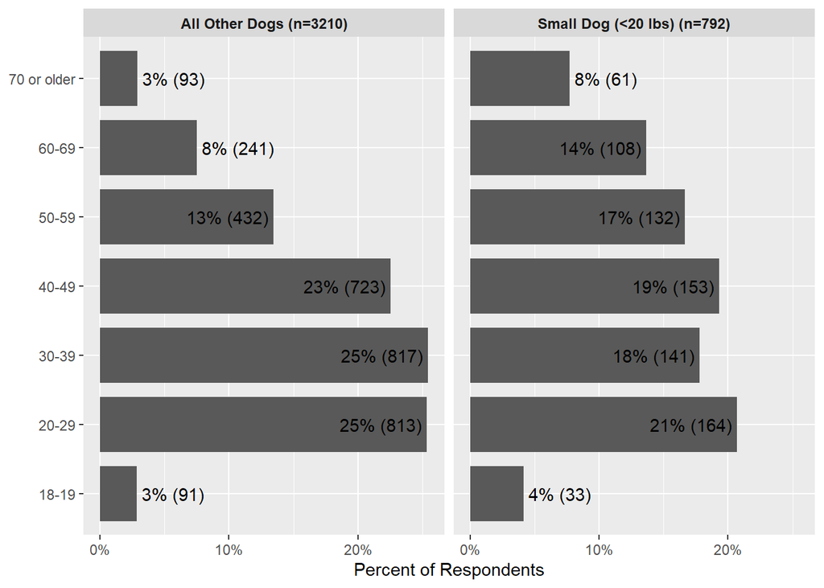

## Q1

**Q1: How old is your puppy now?**

4002 non-empty/NA responses out of 4002 possible responses ( 100 %)

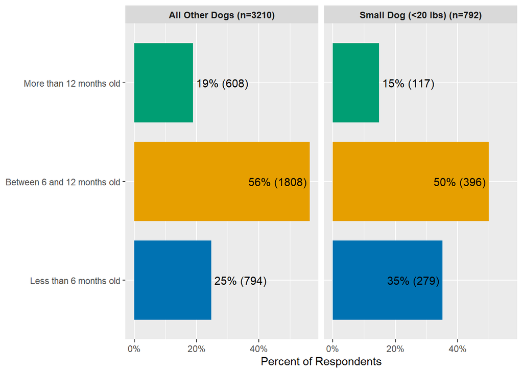

## Q2

**Q2: Are you the puppy’s first owner (besides the breeder, shop, rescue, or shelter where you got your puppy, if applicable)?**

4002 non-empty/NA responses out of 4002 possible responses ( 100 %)

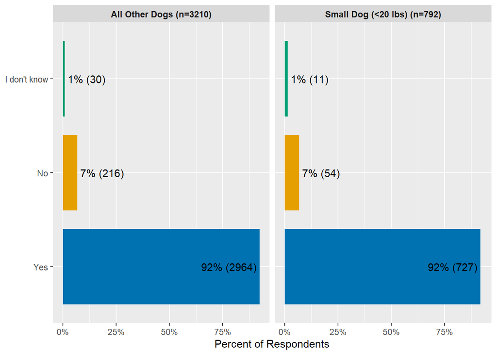

## Q3

**Q3: What is your puppy’s expected size when fully grown?**

4002 non-empty/NA responses out of 4002 possible responses ( 100 %)

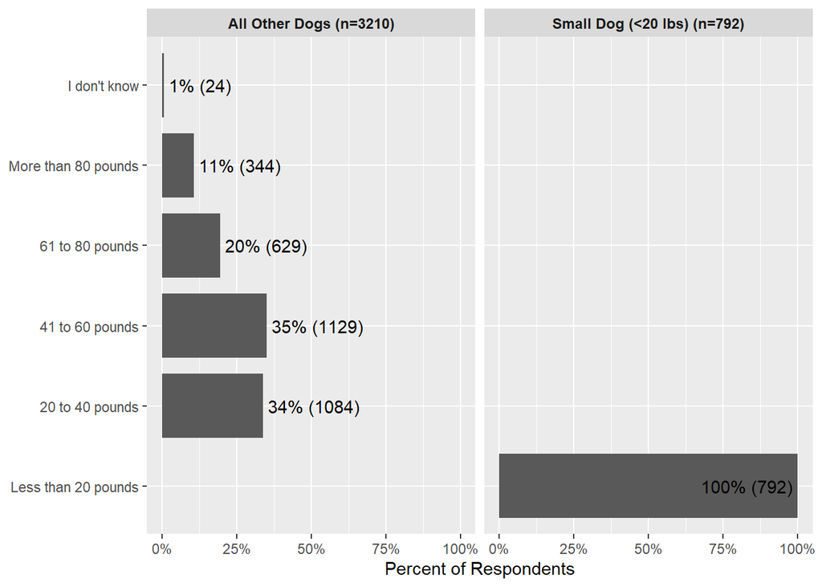

## Q5

**What information do you have on your puppy’s breed?**

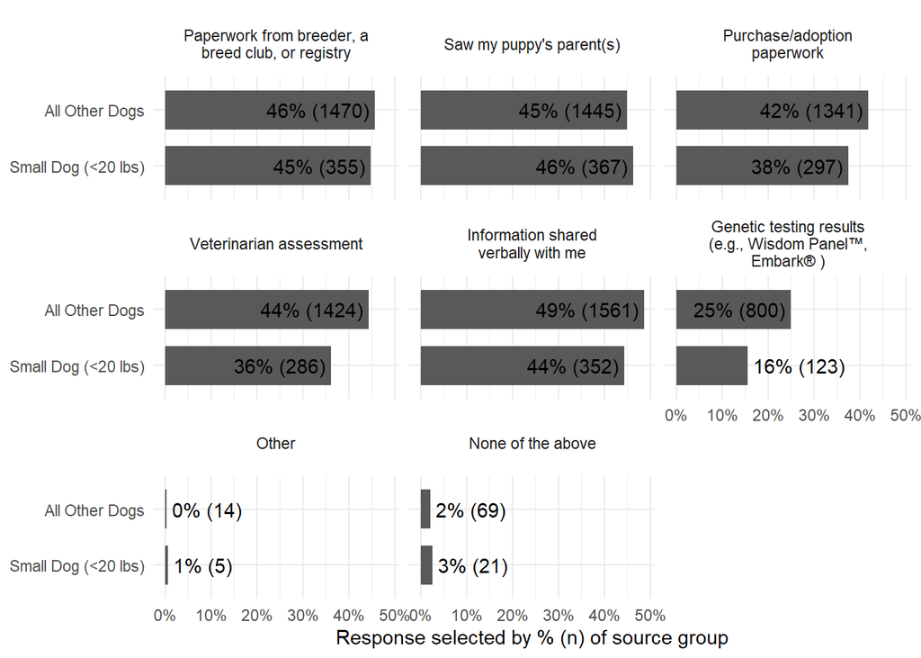

## Q4NEW_new (…)

**Q4: What best describes your puppy’s breed(s)?**

4002 non-empty/NA responses out of 4002 possible responses ( 100 %)

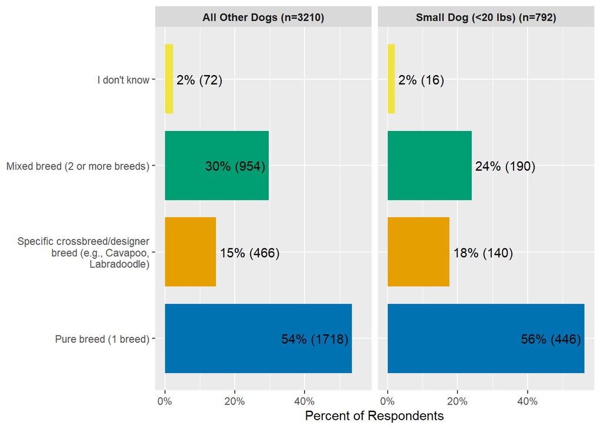

### > Q7

**Breed If answered pure breed**

Showing data for Typology breeds only

| Response | Count | Percent |
| --- | --- | --- |
| Chihuahua | 80 | 18% |
| Yorkshire Terrier | 39 | 9% |
| Shih Tzu | 39 | 9% |
| Pomeranian | 23 | 5% |
| Miniature Dachshund | 20 | 4% |
| American Pit Bull Terrier | 19 | 4% |
|  | 19 | 4% |
| Maltese | 16 | 4% |
| Standard Dachshund | 15 | 3% |
| Pug | 13 | 3% |
| Labrador Retriever | 10 | 2% |
| Golden Retriever | 9 | 2% |
| Miniature Poodle | 9 | 2% |
| Jack Russell Terrier | 8 | 2% |
| French Bulldog | 7 | 2% |
| Cavalier King Charles Spaniel | 7 | 2% |
| Toy Poodle | 7 | 2% |
| Miniature Schnauzer | 7 | 2% |
| German Shepherd Dog | 6 | 1% |
| Boston Terrier | 5 | 1% |
| American Bulldog | 4 | 1% |
| Papillon | 4 | 1% |
| West Highland White Terrier | 4 | 1% |
| Dogue De Bordeaux (French Mastiff) | 4 | 1% |
| Beagle | 3 | 1% |
| Siberian Husky | 3 | 1% |
| Doberman Pinscher | 3 | 1% |
| Miniature Pinscher | 3 | 1% |
| Bichon Frise | 3 | 1% |
| Cocker Spaniel | 3 | 1% |
| Boxer | 2 | 0% |
| Italian Greyhound | 2 | 0% |
| Cairn Terrier | 2 | 0% |
| English Bulldog | 2 | 0% |
| Shetland Sheepdog (Sheltie) | 2 | 0% |
| Miniature American Shepherd | 2 | 0% |
| Dutch Shepherd | 2 | 0% |
| Collie | 2 | 0% |
| Shar-Pei | 2 | 0% |
| Coton De Tulear | 2 | 0% |
| Teacup Poodle | 1 | 0% |
| Standard Poodle | 1 | 0% |
| Pekingese | 1 | 0% |
| American Staffordshire Terrier | 1 | 0% |
| Great Dane | 1 | 0% |
| Rottweiler | 1 | 0% |
| German Long Haired Pointer | 1 | 0% |
| Corgi | 1 | 0% |
| Australian Cattle Dog (Blue Heeler) | 1 | 0% |
| Berger Picard | 1 | 0% |
| Cane Corso | 1 | 0% |
| Purebreed Unknown Name | 1 | 0% |
| Bergamasco Sheepdog | 1 | 0% |
| German Pinscher | 1 | 0% |
| Lhasa Apso | 1 | 0% |
| Klee Kai | 1 | 0% |
| Xl Bully | 1 | 0% |
| Norwich Terrier | 1 | 0% |
| American Water Spaniel | 1 | 0% |
| Mountain Feist | 1 | 0% |
| Samoyed | 1 | 0% |
| Miniature Yorkshire Terrier | 1 | 0% |
| German Shorthaired Pointer | 1 | 0% |
| Manchester Terrier | 1 | 0% |
| Standard Schnauzer | 1 | 0% |
| Tibetan Spaniel | 1 | 0% |
| Havanese | 1 | 0% |
| Rat Terrier | 1 | 0% |
| Australian Silky Terrier | 1 | 0% |
| Teacup Chihuahua | 1 | 0% |
| Teddy Roosevelt Terrier | 1 | 0% |
| Brussels Griffon | 1 | 0% |
| Teacup Yorkie | 1 | 0% |
| English Toy Terrier | 1 | 0% |

### > Q8

**Breed if answered specific crossbreed/designer**

Showing data for Typology breeds only

| Response | Count | Percent |
| --- | --- | --- |
|  | 12 | 9% |
| Chiweenie (Chihuahua / Dachshund) | 9 | 6% |
| Shih-Poo (Shih Tzu / Poodle) | 8 | 6% |
| Chi-Poo (Chihuahua / Poodle) | 7 | 5% |
| Maltipoo (Maltese / Poodle) | 7 | 5% |
| Shorkie Tzu (Yorkie / Shih Tzu) | 6 | 4% |
| Cock-A-Poo (Cocker Spaniel / Poodle) | 5 | 4% |
| Cavapoo (Cavalier King Charles / Toy Poodle) | 4 | 3% |
| Goldendoodle (Golden Retriever / Poodle) | 4 | 3% |
| Pomchi (Pomeranian / Chihuahua) | 4 | 3% |
| Airedoodle (Airedale Terrier / Poodle) | 3 | 2% |
| Goberian (Golden Retriever / Siberian Husky) | 3 | 2% |
| Morkie (Maltese / Yorkie) | 3 | 2% |
| Labradoodle (Labrador / Poodle) | 3 | 2% |
| Malti-Pom (Maltese / Pomeranian) | 3 | 2% |
| Yorkipoo (Yorkie / Poodle) | 3 | 2% |
| Mal-Shi (Maltese / Shih Tzu) | 3 | 2% |
| Chorkie (Chihuahua / Yorkie) | 2 | 1% |
| American Rat Pinscher (Rat Terrier / Min Pinscher) | 2 | 1% |
| Shichon (Bichon Frisé / Shih Tzu) | 2 | 1% |
| Bagle (Beagle / Basset) | 2 | 1% |
| American Bullador (American Bulldog / Labrador) | 2 | 1% |
| Golden Shepherd (Golden Retriever / German Shepherd) | 2 | 1% |
| Designer Unknown Breed | 2 | 1% |
| Puggle (Pug / Beagle) | 2 | 1% |
| Aussiedoodle (Australian Shepherd / Poodle) | 2 | 1% |
| Chug (Chihuahua / Pug) | 2 | 1% |
| Bocker (Beagle / Cocker Spaniel) | 2 | 1% |
| Beaglier (Beagle / Cavalier King Charles Spaniel) | 2 | 1% |
| American Bull Dogue De Bordeaux (American Bulldog / Dogue De Bordeaux) | 1 | 1% |
| American Boston Bull Terrier (American Pitbull Terrier / Boston Terrier) | 1 | 1% |
| Aussiepom (Australian Shepherd / Pomeranian) | 1 | 1% |
| Frenchie Pug (French Bulldog / Pug) | 1 | 1% |
| Affen Border Terrier (Affenpincher / Border Terrier) | 1 | 1% |
| Schnoodle (Mini Schnauzer / Poodle) | 1 | 1% |
| Rat-Cha (Rat Terrier / Chihuahua) | 1 | 1% |
| Malchi (Maltese / Chihuahua) | 1 | 1% |
| American Heeler (Australian Shepherd / Australian Cattledog) | 1 | 1% |
| Bichonpoo (Bichon Frise / Miniature Poodle) | 1 | 1% |
| Boweimar (Weimeraner / Boxer) | 1 | 1% |
| Doberdor (Doberman Pincher / Labrador) | 1 | 1% |
| Golden Labrador (Golden Retriever / Labrador) | 1 | 1% |
| Miniature Goldendoodle (Golden Retriever / Toy Poodle) | 1 | 1% |
| Corkie (Cairn Terrier / Yorkie) | 1 | 1% |
| Bernedoodle (Bernese Mt Dog / Poodle) | 1 | 1% |
| Miniature Sheepadoodle (Old English Sheepdog / Toy Poodle) | 1 | 1% |
| Pomsky (Pomeranian / Siberian Husky) | 1 | 1% |
| Bulloxer (Bulldog / Boxer) | 1 | 1% |
| Maltichon (Maltese / Bichon Frise) | 1 | 1% |
| Cava-Tzu (Cavalier King Charles / Shih Tzu) | 1 | 1% |
| Silky Chi (Silky Terrier / Chihuahua) | 1 | 1% |
| Chipin (Chihuahua / Mini Pinshcer) | 1 | 1% |
| Affenchon (Affenpinscher / Bichon Frise) | 1 | 1% |
| Sheep-A-Poo (Old English Sheepdog / Poodle) | 1 | 1% |
| Havashire (Yorkshire Terrier / Havanese) | 1 | 1% |
| Poochon (Poodle / Bischon Frise) | 1 | 1% |
| Morkie (Maltese / Yorkie) And A Dorkie (Dachshund / Yorkie) | 1 | 1% |
| Shiffon (Brussels Griffon /Shih Tzu) | 1 | 1% |

### > Q9 (…)

**Breed if answered mixed breed**

Showing data for Typology breeds only

| Response | Count | Percent |
| --- | --- | --- |
| Chihuahua | 53 | 28% |
|  | 25 | 13% |
| Yorkshire Terrier | 10 | 5% |
| Shih Tzu | 8 | 4% |
| Miniature Poodle | 7 | 4% |
| Standard Dachshund | 7 | 4% |
| Jack Russell Terrier | 6 | 3% |
| Miniature Dachshund | 6 | 3% |
| Labrador Retriever | 4 | 2% |
| American Pit Bull Terrier | 4 | 2% |
| Maltese | 4 | 2% |
| Toy Poodle | 3 | 2% |
| Pomeranian | 3 | 2% |
| American Staffordshire Terrier | 2 | 1% |
| American Bulldog | 2 | 1% |
| Beagle | 2 | 1% |
| Rat Terrier | 2 | 1% |
| Cane Corso | 2 | 1% |
| Pug | 2 | 1% |
| Standard Poodle | 2 | 1% |
| Doberman Pinscher | 2 | 1% |
| Cairn Terrier | 2 | 1% |
| Corgi | 2 | 1% |
| Dalmatian | 2 | 1% |
| Chow Chow | 1 | 1% |
| Bichon Frise | 1 | 1% |
| Pit Bull | 1 | 1% |
| Boxer | 1 | 1% |
| Alaskan Malamute | 1 | 1% |
| Airedale Terrier | 1 | 1% |
| Pekingese | 1 | 1% |
| Rottweiler | 1 | 1% |
| German Long Haired Pointer | 1 | 1% |
| Australian Shepherd | 1 | 1% |
| Australian Silky Terrier | 1 | 1% |
| Basset Hound | 1 | 1% |
| American Bully | 1 | 1% |
| Anatolian Shepherd | 1 | 1% |
| Cocker Spaniel | 1 | 1% |
| Shiba Inu | 1 | 1% |
| Pom’shz | 1 | 1% |
| Morky | 1 | 1% |
| Fox Terrier | 1 | 1% |
| Dogue de Bordeaux (French Mastiff) | 1 | 1% |
| Lhasa Apso | 1 | 1% |
| Pomachi | 1 | 1% |
| Moyen Poodle | 1 | 1% |
| Miniature Pinscher | 1 | 1% |
| Havermese | 1 | 1% |
| Scottish Terrier | 1 | 1% |
| Irish Terrier | 1 | 1% |
| Miniature Schnauzer | 1 | 1% |

#### >> Q10

**Q10: Would you like to add a second breed for your puppy?**

1144 non-empty/NA responses out of 1144 possible responses ( 100 %)

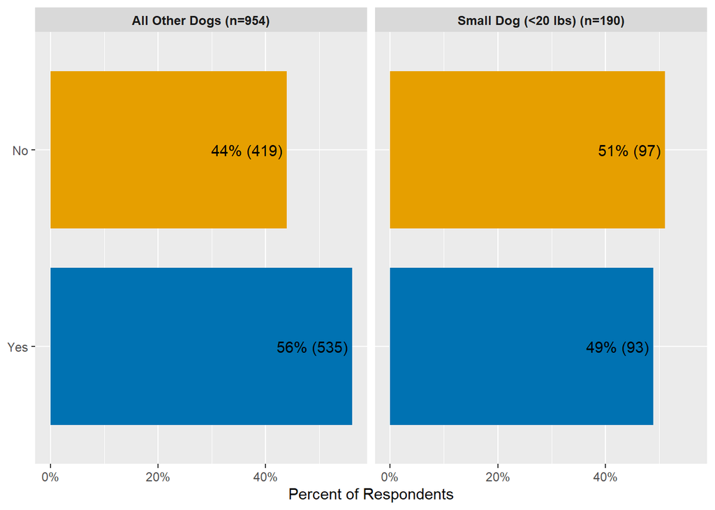

#### >> Q11

**Q11: Text - What is your puppy’s secondary breed? Please type the name in the text box below. It is okay if you are not certain of the breed; please provide your best guess. Select “I don’t know” only if you have no information on the breed.**

Showing data for Typology breeds only

| Response | Count | Percent |
| --- | --- | --- |
| Chihuahua | 11 | 12% |
| Jack Russell Terrier | 9 | 10% |
| Miniature Poodle | 8 | 9% |
| Yorkshire Terrier | 6 | 6% |
| Pug | 4 | 4% |
| Maltese | 4 | 4% |
|  | 4 | 4% |
| Miniature Dachshund | 4 | 4% |
| Standard Dachshund | 3 | 3% |
| American Staffordshire Terrier | 3 | 3% |
| Shih Tzu | 3 | 3% |
| Pit Bull | 2 | 2% |
| Golden Retriever | 2 | 2% |
| Airedale Terrier | 2 | 2% |
| Standard Poodle | 2 | 2% |
| Pomeranian | 2 | 2% |
| American Pit Bull Terrier | 1 | 1% |
| Beagle | 1 | 1% |
| Pekingese | 1 | 1% |
| Irish Wolfhound | 1 | 1% |
| German Shepherd Dog | 1 | 1% |
| Labrador Retriever | 1 | 1% |
| Siberian Husky | 1 | 1% |
| Berger Picard | 1 | 1% |
| Miniature Pinscher | 1 | 1% |
| Chow Chow | 1 | 1% |
| Alaskan Malamute | 1 | 1% |
| Terrier | 1 | 1% |
| Miniature Schnauzer | 1 | 1% |
| Border Collie | 1 | 1% |
| West Highland Terrier | 1 | 1% |
| Australian Shepherd | 1 | 1% |
| Yorkie | 1 | 1% |
| Staffordshire Bull Terrier | 1 | 1% |
| Pom | 1 | 1% |
| Mini Collie | 1 | 1% |
| Wire Haired Terrier | 1 | 1% |
| Carin Terrier | 1 | 1% |
| English Toy Spaniel | 1 | 1% |
| Shetland Sheepdog (Sheltie) | 1 | 1% |

## Q12 (…)

**Q12: Is your puppy sterilized (spayed or neutered)?**

4002 non-empty/NA responses out of 4002 possible responses ( 100 %)

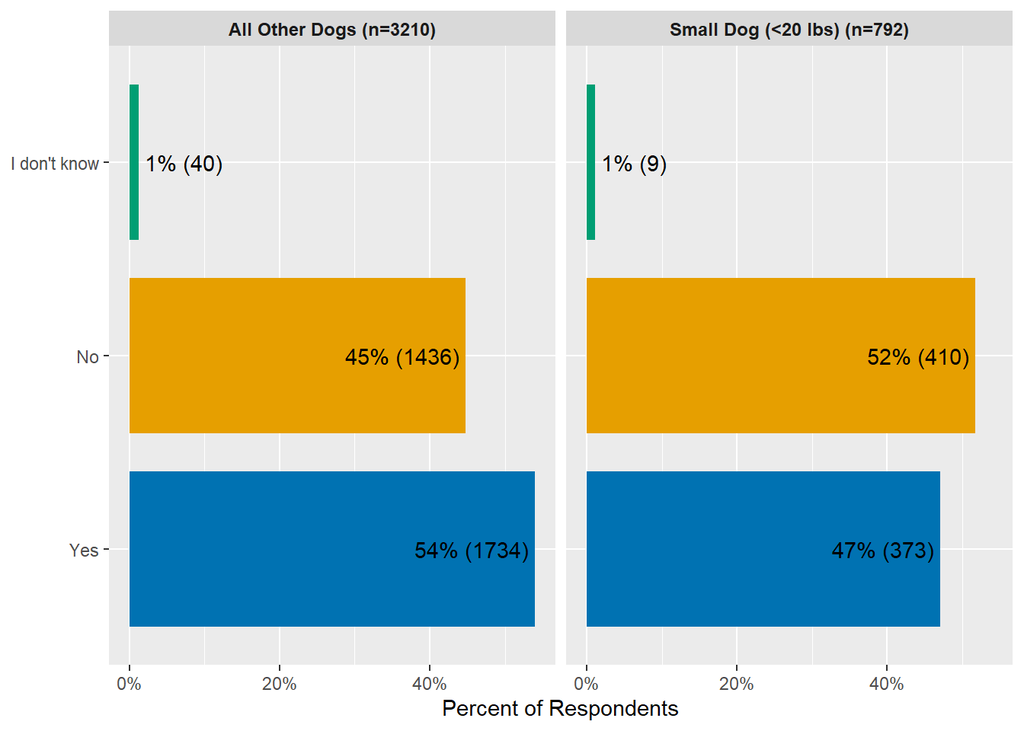

### > Q13 (…)

**Q13: Was your puppy sterilized before you brought them home?**

2107 non-empty/NA responses out of 2107 possible responses ( 100 %)

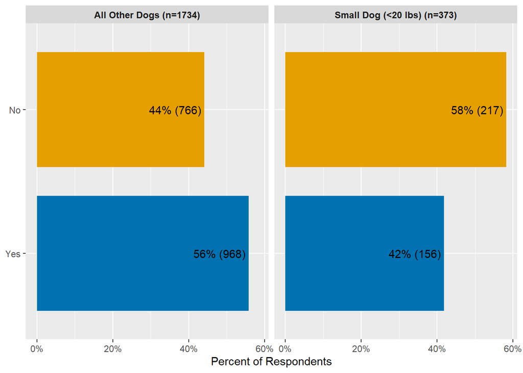

#### >> Q13a

**Q13a: At what age were they sterilized?**

983 non-empty/NA responses out of 983 possible responses ( 100 %)

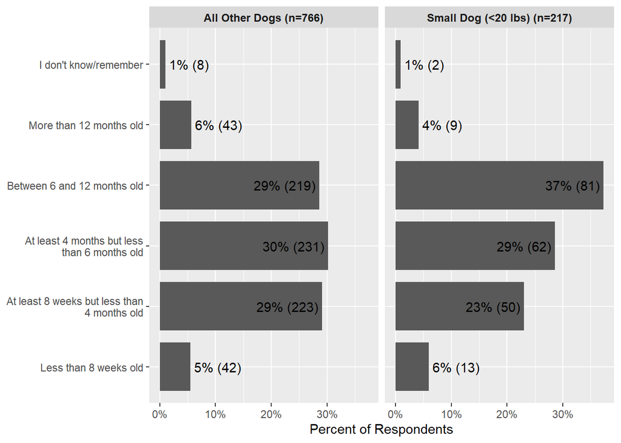

#### >> Q13b

**Q13b: Where did your puppy have their spay/neuter surgery?**

983 non-empty/NA responses out of 983 possible responses ( 100 %)

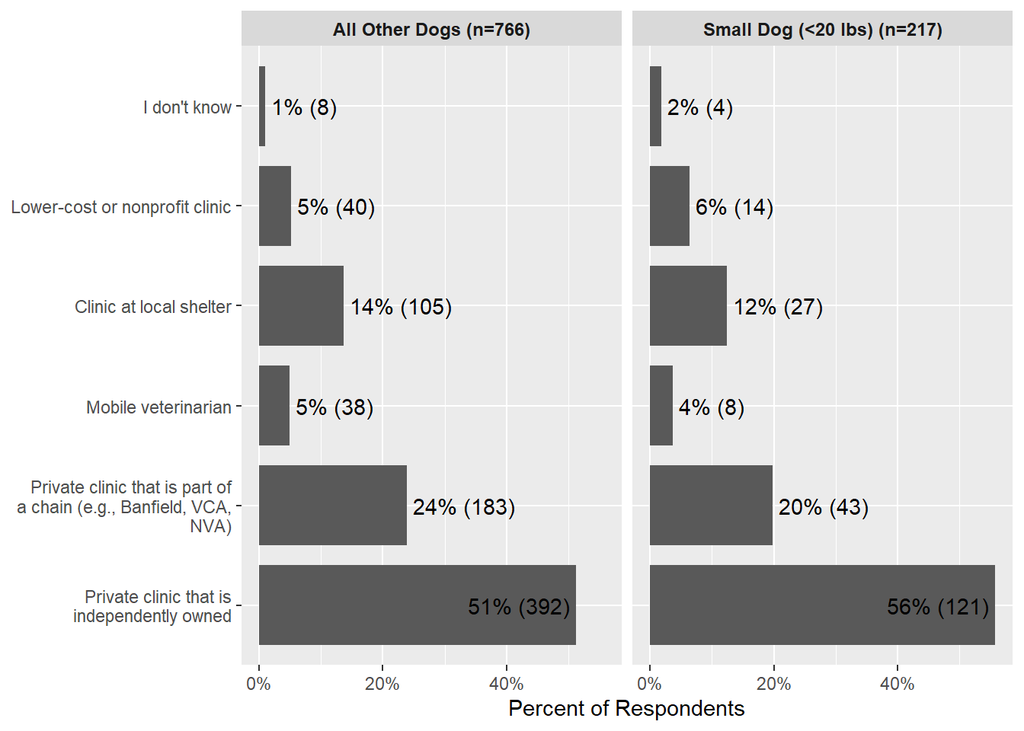

#### >> Q13c (…)

**Q13c: Has your puppy gone to a veterinarian since you got them other than for spay/neuter surgery?**

983 non-empty/NA responses out of 983 possible responses ( 100 %)

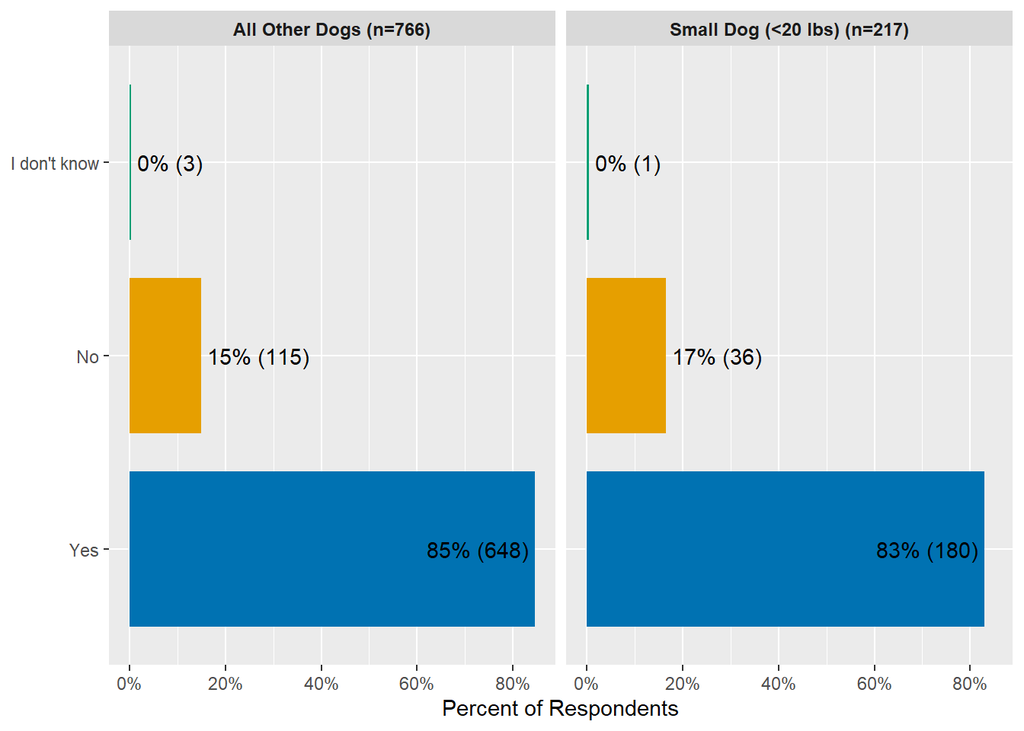

##### >>> Q13d

**Where has your puppy gone for other veterinary care?**

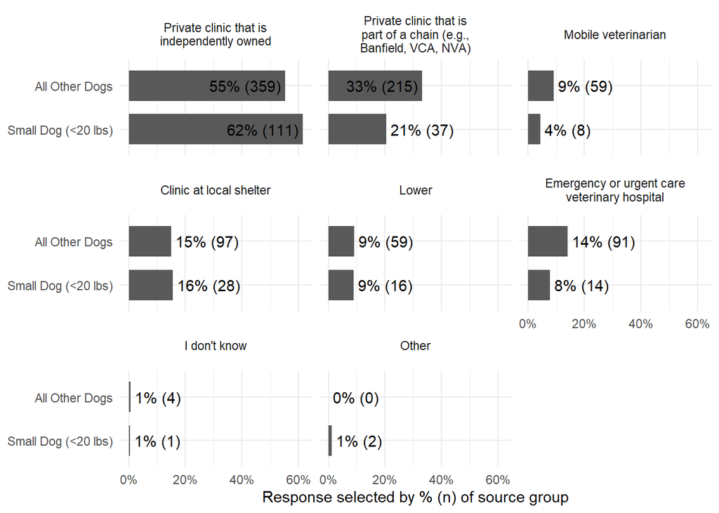

### > Q14

**Q14: Do you plan to breed your puppy in the future?**

1846 non-empty/NA responses out of 1895 possible responses ( 97 %)

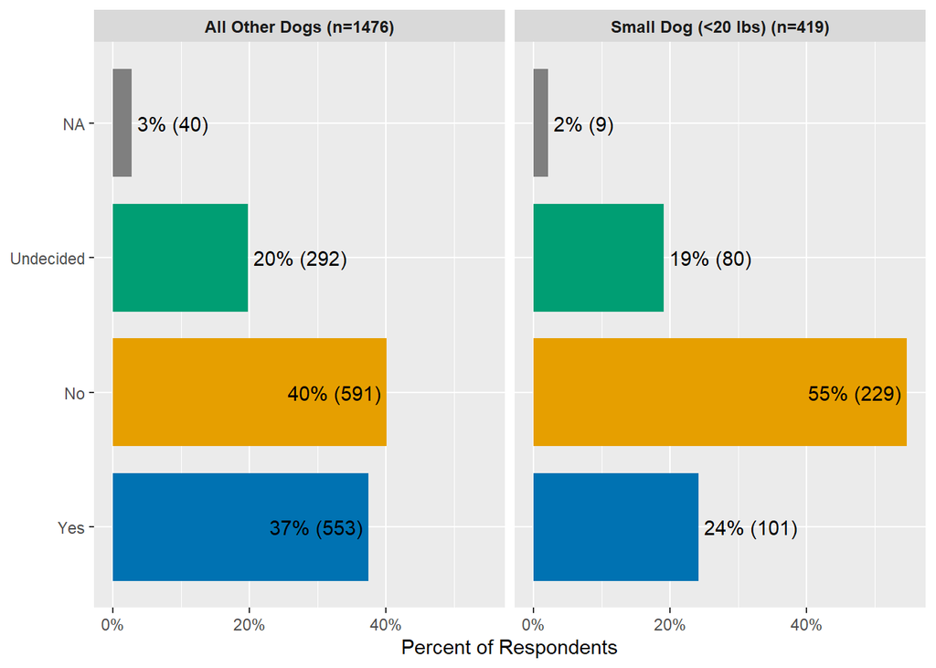

### > Q14a

**Q14a: Do you plan to sterilize your puppy in the future?**

1846 non-empty/NA responses out of 1895 possible responses ( 97 %)

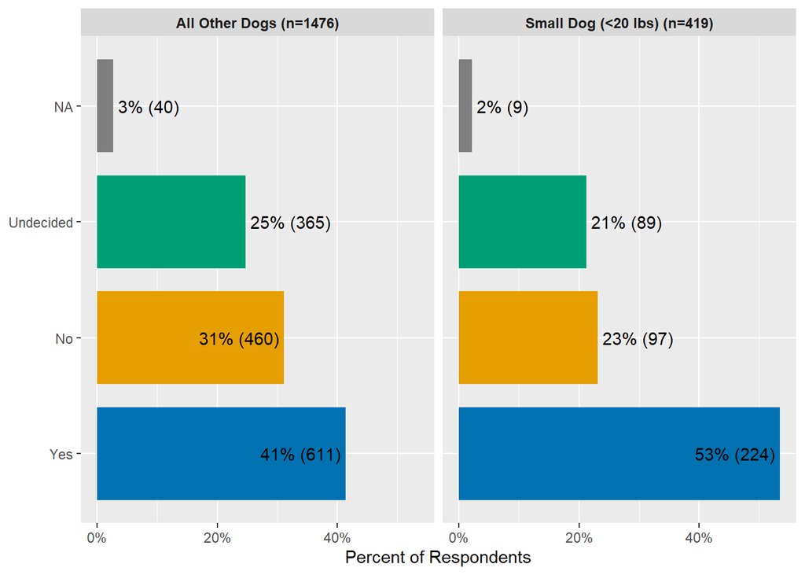

### > Q15

**Q15: Has your puppy gone to a veterinarian since you got them?**

3019 non-empty/NA responses out of 3019 possible responses ( 100 %)

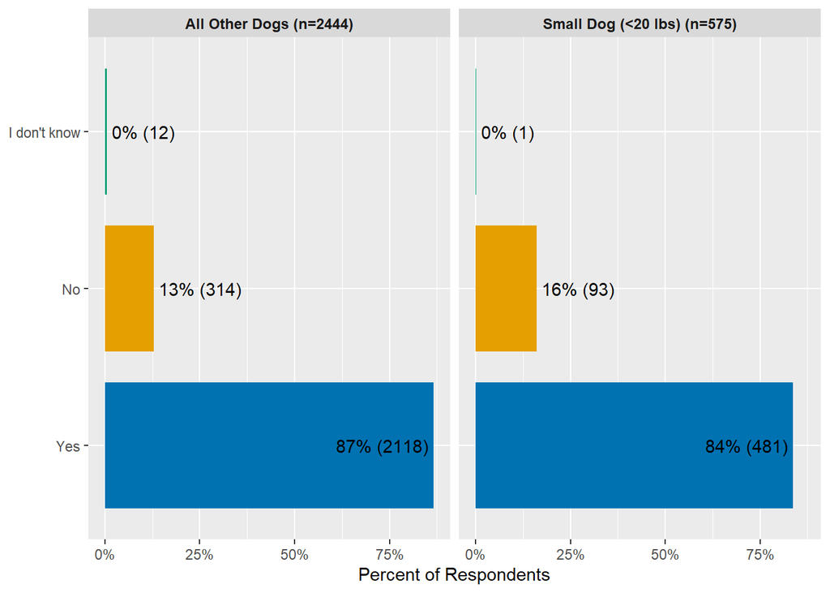

### > Q16

**Where has your puppy gone for veterinary care?**

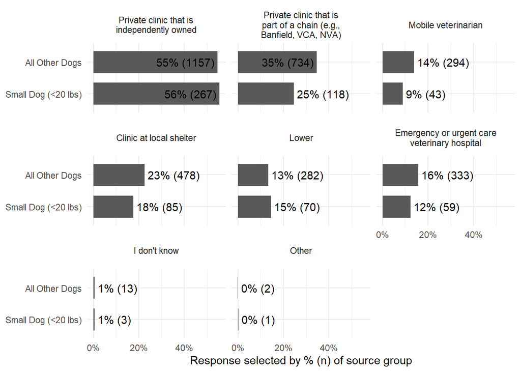

## Q17

**Q17: Before this puppy, were you ever a primary caretaker for a dog as an adult (when you were age 18 or older)?**

4002 non-empty/NA responses out of 4002 possible responses ( 100 %)

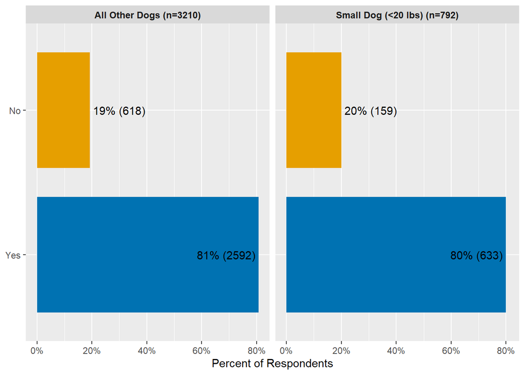

## Group A Only (…)

**Group A Only**

### > Timing and Availability

### > Q18 (…)

**Q18: How much time did you spend searching for a puppy?**

2001 non-empty/NA responses out of 2001 possible responses ( 100 %)

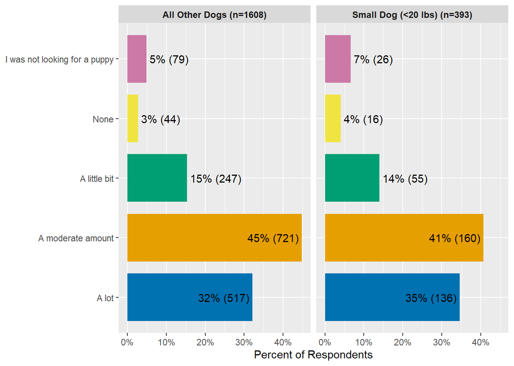

#### >> Q19

**You shared that you didn’t spend time searching for your puppy. Did any of the following apply to you getting your puppy?**

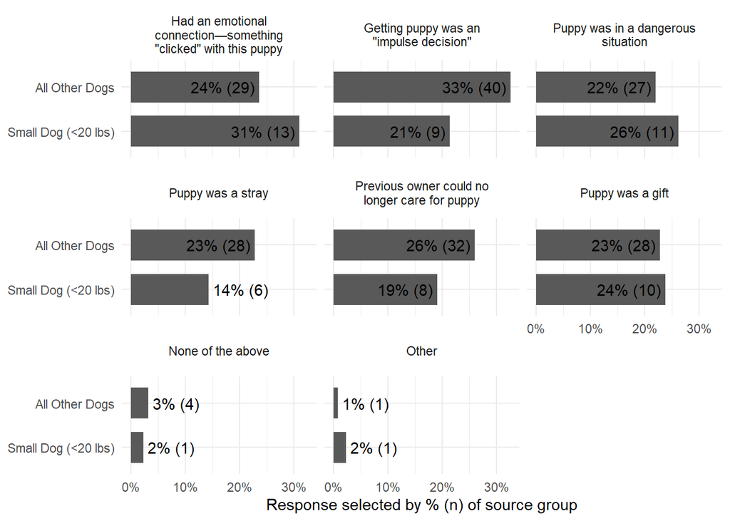

#### >> Q20

**Q20: How long was it from the time you started looking for a puppy to when you first brought your puppy home?**

1836 non-empty/NA responses out of 1836 possible responses ( 100 %)

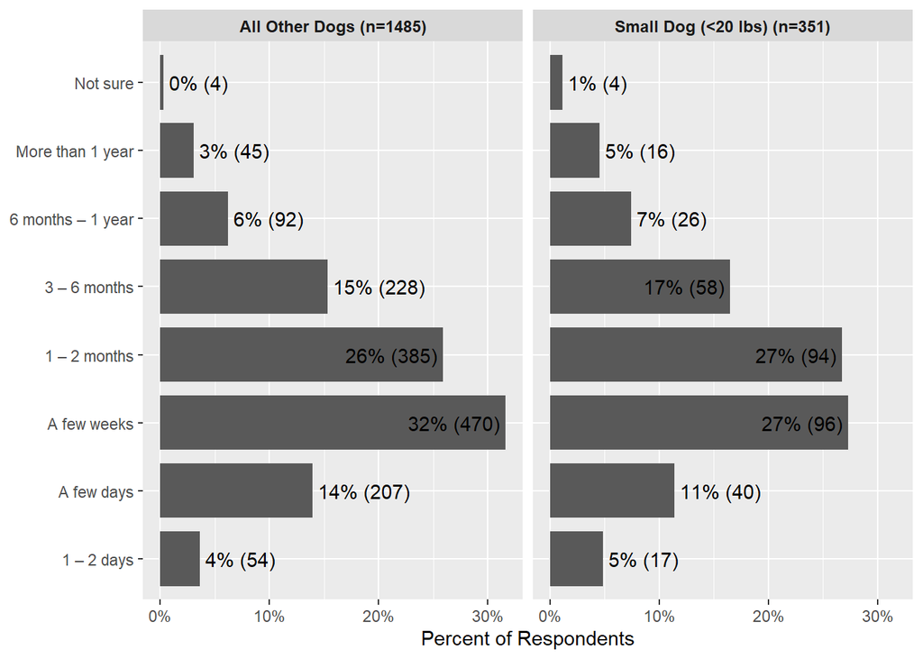

#### >> Q21 (…)

**Q21: How did this compare to the time you expected it would take?**

1836 non-empty/NA responses out of 1836 possible responses ( 100 %)

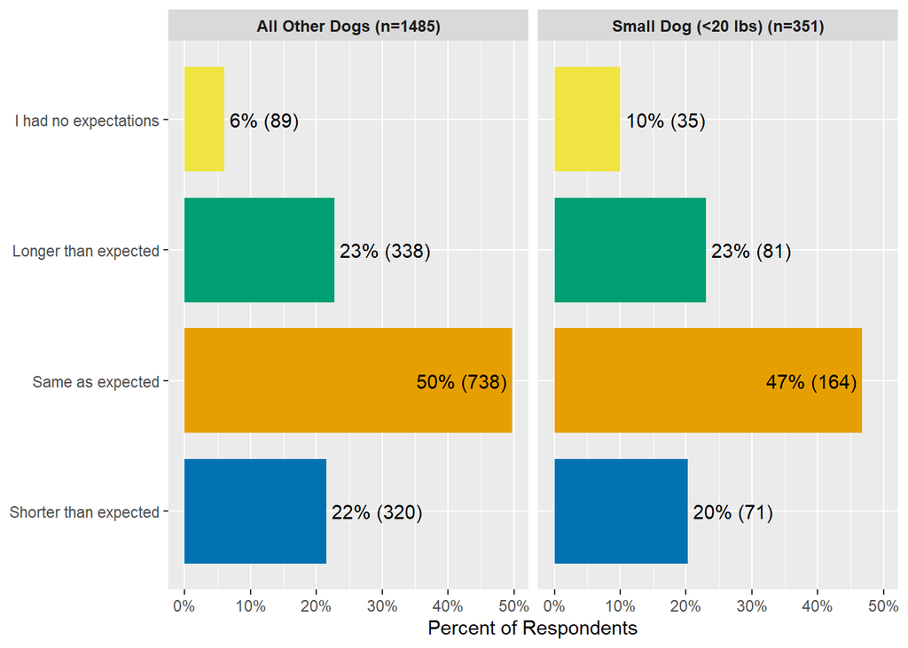

##### >>> Q22

**Why do you think it took as long as it did to get a puppy?**

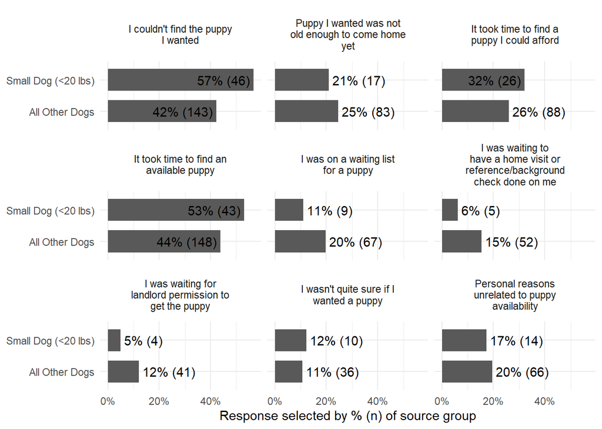

##### >>> Q23

**Why do you think you got your puppy faster than expected?**

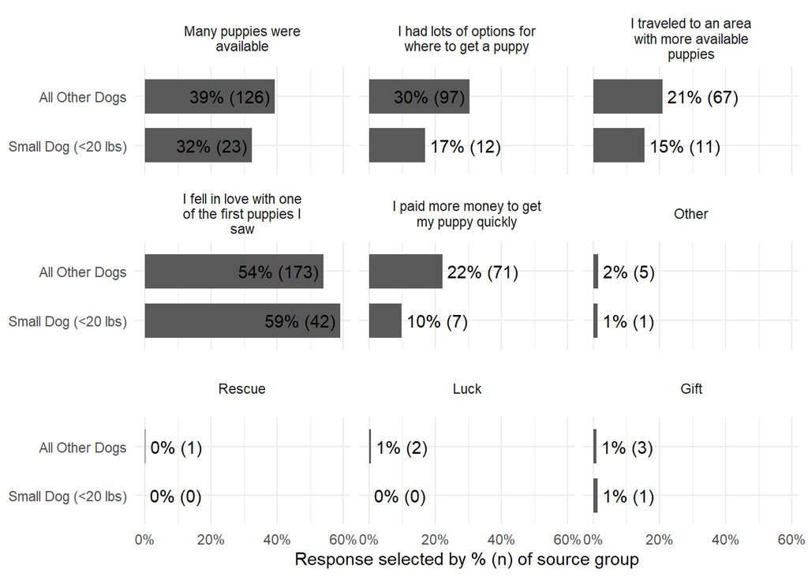

#### >> Motivation/Preferences for Puppy Features

#### >> Q24

**Q24: How closely did the puppy you got match what you were searching for?**

1896 non-empty/NA responses out of 1896 possible responses ( 100 %)

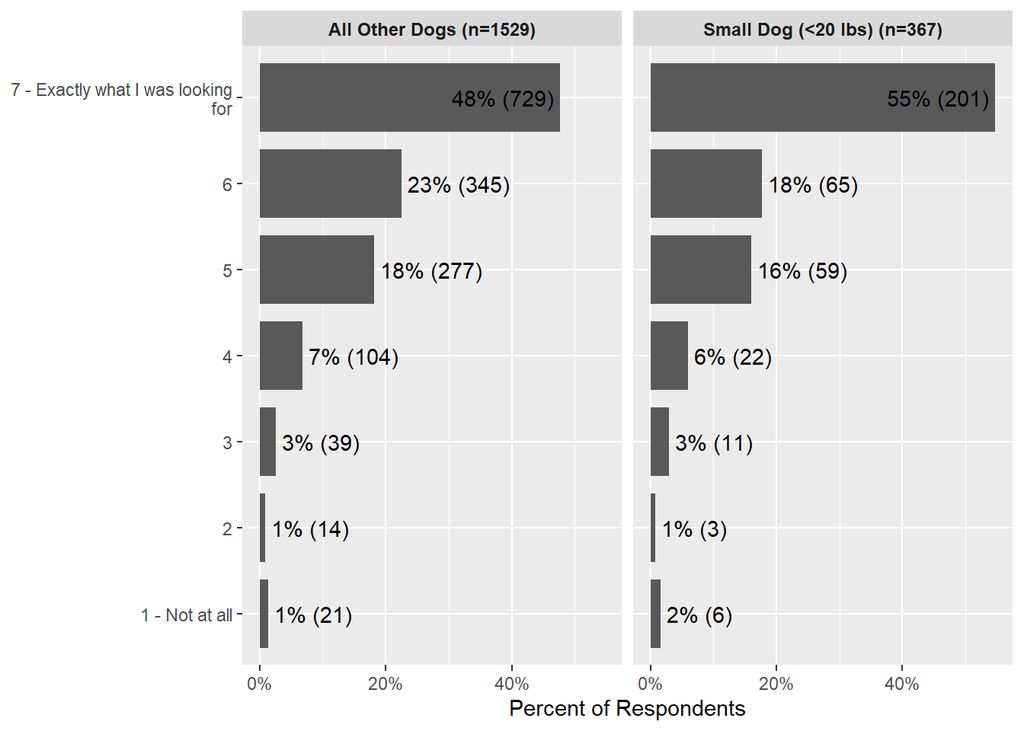

#### >> Q25 (…)

**How important were each of the following in choosing your puppy?**

1896 total non-empty/NA responses from 1896 possible respondents ( 100 %)

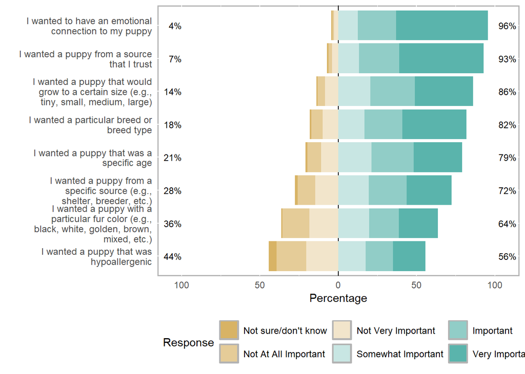

##### >>> Q25

**Q25r1: I wanted a puppy from a specific source (e.g., shelter, breeder, etc.) - How important were each of the following in choosing your puppy?**

1896 non-empty/NA responses out of 1896 possible responses ( 100 %)

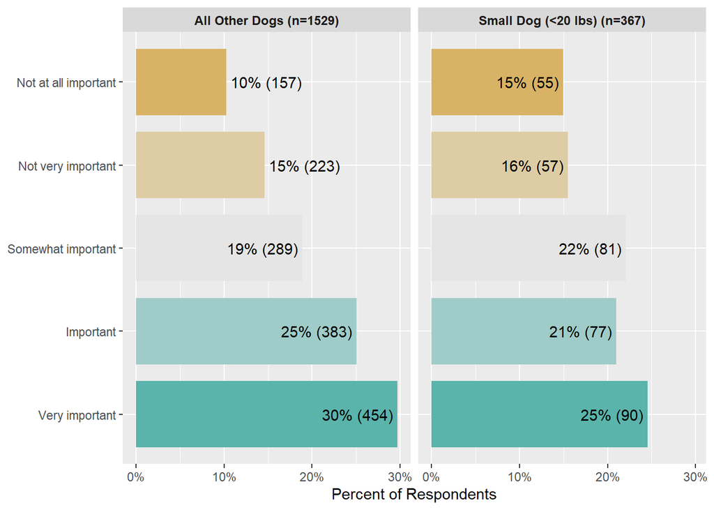

##### >>> Q25r2

**Q25r2: I wanted a puppy that was a specific age - How important were each of the following in choosing your puppy?**

1896 non-empty/NA responses out of 1896 possible responses ( 100 %)

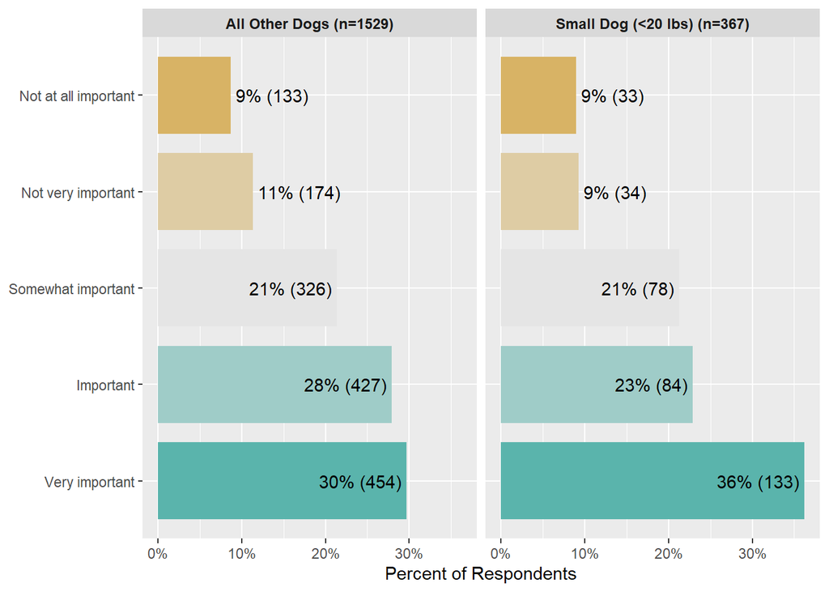

##### >>> Q25r3

**Q25r3: I wanted a puppy that would grow to a certain size (e.g., tiny, small, medium, large) - How important were each of the following in choosing your puppy?**

1896 non-empty/NA responses out of 1896 possible responses ( 100 %)

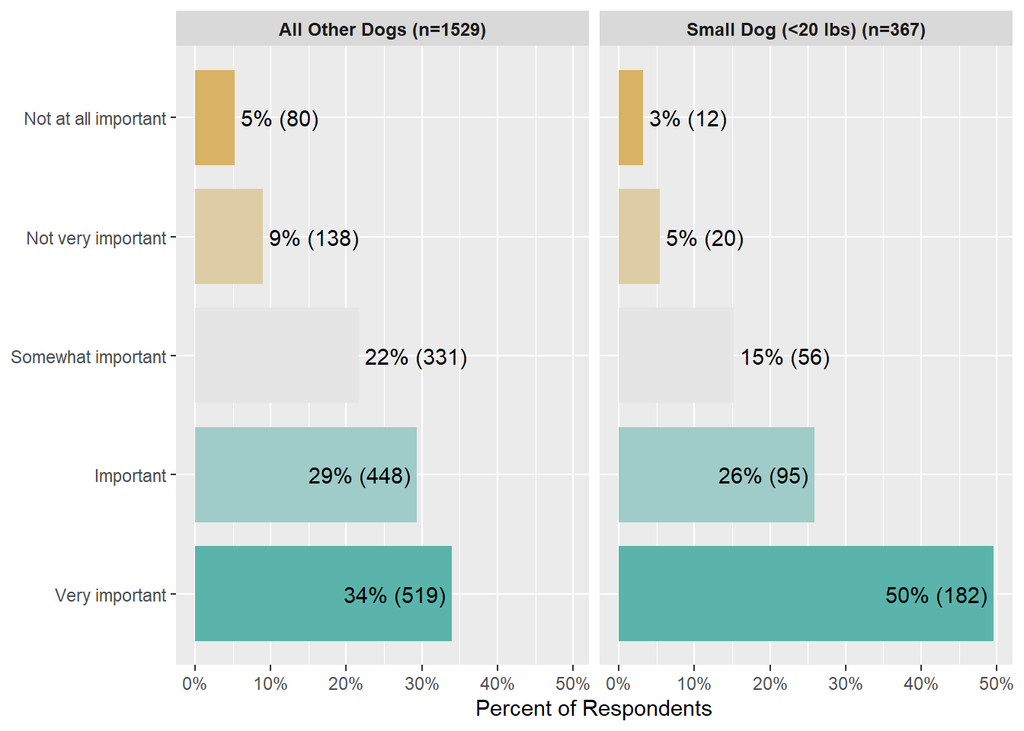

##### >>> Q25r4

**Q25r4: I wanted a particular breed or breed type - How important were each of the following in choosing your puppy?**

1896 non-empty/NA responses out of 1896 possible responses ( 100 %)

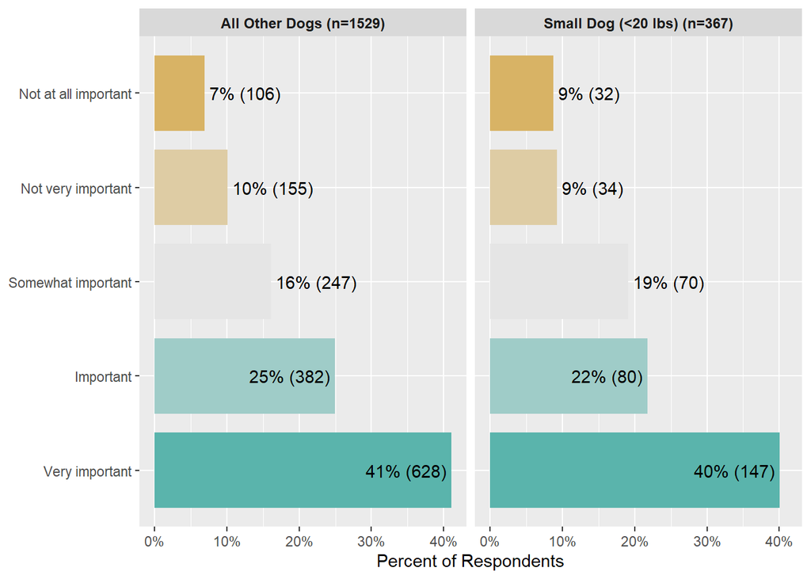

##### >>> Q25r5

**Q25r5: I wanted to have an emotional connection to my puppy - How important were each of the following in choosing your puppy?**

1896 non-empty/NA responses out of 1896 possible responses ( 100 %)

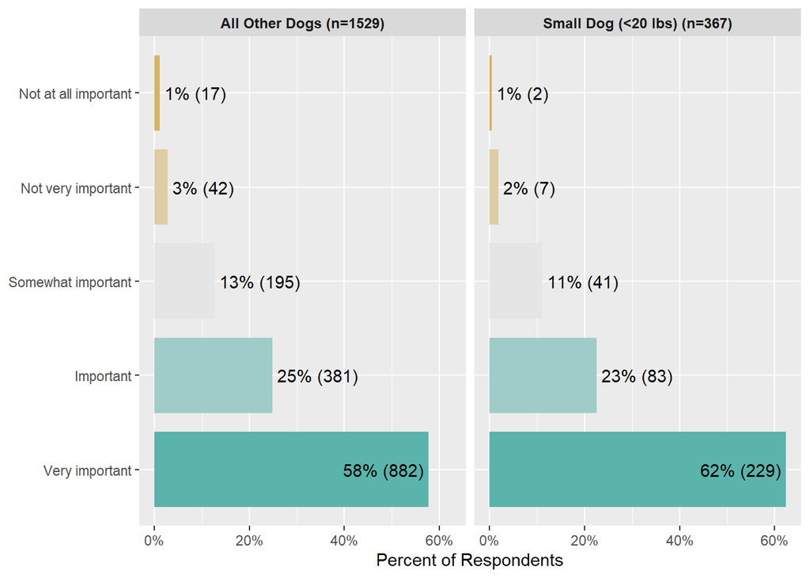